# Blogdown Presentation

11/16/2019

## Pre-Talk

Set the RStudio to install blogdown.

```
install.packages("blogdown")
```

and to get a working local version of Hugo, the static site generator at the heart of this,

```
blogdown::install_hugo()
```

## Motivation

[figure not shown]

## Alison Hill’s magnificent resources on this.

[The Blogdown Book](https://bookdown.org/yihui/blogdown/)

[Summer of Blogdown](https://summer-of-blogdown.netlify.com/)

I wish I had them when I had to figure this all out for myself.

## Why Blogdown

[figure not shown]

## Workflow

Navigate to the [github base for this](https://github.com/WUCDS1920/blankslate).

[figure not shown]

Go!

## Create a github site

If you do not already have one, you will need to create a github site. I created one for today called wucds1920 – Willamette University Certificate in Data Science 19/20. *I would associate it with a professional durable email account.*

[figure not shown]

Go!

## Fork blankslate

[figure not shown]

## Migrate to your fork

[figure not shown]

Go!

## The Action

[figure not shown]

## The Magic of GitHub

My objectives are more limited. We want to Start a New Project…

From our github

We may need:

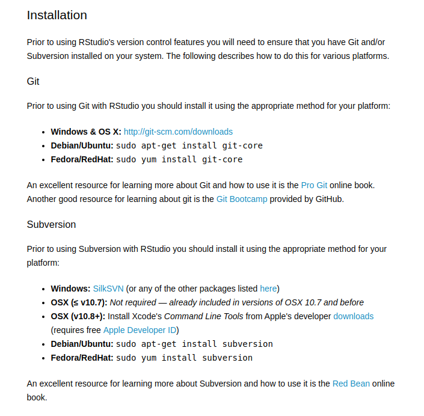

## Let’s Edit….

> just typing R code - Hadley Wickham

## Change the name

And some associated content. Only a bit at a time.

## For Fun: A First Post?

Addins : New Post

Something pretty simple.

## Code

```
data("UCBAdmissions")
# install.packages("ggalluvial")
library(tidyverse); library(ggalluvial)
ggplot(as.data.frame(UCBAdmissions), # Flatten the table
       aes(y = Freq, axis1 = Gender, axis2 = Dept)) +
  geom_alluvium(aes(fill = Admit), width = 1/12) +
  geom_stratum(width = 1/12, fill = "black", color = "grey") +
  geom_label(stat = "stratum", label.strata = TRUE) +
  scale_x_discrete(limits = c("Gender", "Dept"), expand = c(.05, .05)) +
  scale_fill_brewer(type = "qual", palette = "Set1") +
  ggtitle("Admissions by sex and department: UCB") + labs(caption = "A ggallvial example")
```

## A Picture

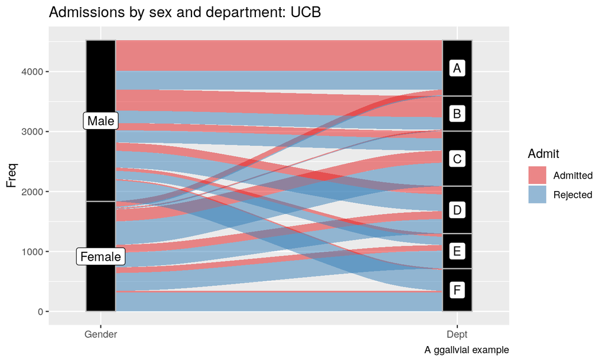

## First a commit.

Now we are going to undertake our first interaction with GitHub from RStudio.

Stage all the changes and produce an informative commit message. My first post and the initial edits to blankslate or something like that.

## To Netlify

And check out the deployment. In the meantime, we can, and probably should, copy off the deployment part from Netlify so we can check the status without logging in. We should also edit README.md to make the deploy button unique to our fork.